# Congress demographics

Nataliya Ferdinand

2024-09-01

# **Introduction:**

The article discusses the increasing age of the U.S. Congress, noting that it is older now than ever before, with a median age of 59 years. It highlights the challenges this aging body faces, particularly in understanding modern technology, and the impact of having older members on legislative priorities, which tend to focus more on issues concerning older Americans. The article also suggests that the age trend in Congress might plateau or decline as younger generations like Gen X and Millennials gradually replace the aging baby boomers.

The link to the article: **https://fivethirtyeight.com/features/aging-congress-boomers/**

Reading the whole .csv file. The path to the .csv file is from GitHub repository.

The data has 29,120 rows. The output just shows first 10 rows.

```r
file_path<-"https://raw.githubusercontent.com/Natacode819/Data-607-Assignment1/main/data_aging_congress.csv"
datacongress<-read.csv(file_path)
head(datacongress, 10)
```

```
##    congress start_date chamber state_abbrev party_code                 bioname
## 1        82 1951-01-03   House           ND        200    AANDAHL, Fred George
## 2        80 1947-01-03   House           VA        100 ABBITT, Watkins Moorman
## 3        81 1949-01-03   House           VA        100 ABBITT, Watkins Moorman
## 4        82 1951-01-03   House           VA        100 ABBITT, Watkins Moorman
## 5        83 1953-01-03   House           VA        100 ABBITT, Watkins Moorman
## 6        84 1955-01-03   House           VA        100 ABBITT, Watkins Moorman
## 7        85 1957-01-03   House           VA        100 ABBITT, Watkins Moorman
## 8        86 1959-01-03   House           VA        100 ABBITT, Watkins Moorman
## 9        87 1961-01-03   House           VA        100 ABBITT, Watkins Moorman
## 10       88 1963-01-03   House           VA        100 ABBITT, Watkins Moorman
##    bioguide_id   birthday cmltv_cong cmltv_chamber age_days age_years
## 1      A000001 1897-04-09          1             1    19626  53.73306
## 2      A000002 1908-05-21          1             1    14106  38.62012
## 3      A000002 1908-05-21          2             2    14837  40.62149
```

[output cut: 18 more lines]

**Checking missing values**

There are various techniques in statistical programs to represent missing data. R uses NA. I checked whether there are any missing values in the data. I used is.na() function. The output shows that there are no missing data in any columns in the file.

```r
na_counts<-colSums(is.na(datacongress))
print(na_counts)
```

```
##      congress    start_date       chamber  state_abbrev    party_code
##             0             0             0             0             0
##       bioname   bioguide_id      birthday    cmltv_cong cmltv_chamber
##             0             0             0             0             0
##      age_days     age_years    generation
##             0             0             0
```

Another way to check whether there are any missing values using sapply() function.

```r
na_columns<-sapply(datacongress,anyNA)
print(na_columns)
```

```
##      congress    start_date       chamber  state_abbrev    party_code
##         FALSE         FALSE         FALSE         FALSE         FALSE
##       bioname   bioguide_id      birthday    cmltv_cong cmltv_chamber
##         FALSE         FALSE         FALSE         FALSE         FALSE
##      age_days     age_years    generation
##         FALSE         FALSE         FALSE
```

**Summary function:**

Sometimes it is useful to get a basic summary (min, max, median, mean, …) for each variable of the data

```r
summary(datacongress)
```

```
##     congress       start_date          chamber          state_abbrev
##  Min.   : 66.00   Length:29120       Length:29120       Length:29120
##  1st Qu.: 79.00   Class :character   Class :character   Class :character
##  Median : 92.00   Mode  :character   Mode  :character   Mode  :character
##  Mean   : 91.88
##  3rd Qu.:105.00
##  Max.   :118.00
##    party_code      bioname          bioguide_id          birthday
##  Min.   :100.0   Length:29120       Length:29120       Length:29120
##  1st Qu.:100.0   Class :character   Class :character   Class :character
##  Median :100.0   Mode  :character   Mode  :character   Mode  :character
##  Mean   :146.7
##  3rd Qu.:200.0
##  Max.   :537.0
##    cmltv_cong     cmltv_chamber       age_days       age_years
##  Min.   : 1.000   Min.   : 1.000   Min.   : 8644   Min.   :23.67
##  1st Qu.: 2.000   1st Qu.: 2.000   1st Qu.:16732   1st Qu.:45.81
##  Median : 4.000   Median : 4.000   Median :19523   Median :53.45
##  Mean   : 5.414   Mean   : 5.112   Mean   :19626   Mean   :53.73
##  3rd Qu.: 8.000   3rd Qu.: 7.000   3rd Qu.:22359   3rd Qu.:61.22
##  Max.   :30.000   Max.   :30.000   Max.   :35824   Max.   :98.08
##   generation
##  Length:29120
##  Class :character
##  Mode  :character
##
##
##
```

**Checking the data type**

```r
class(datacongress)
```

```
## [1] "data.frame"
```

**List of all variables in the data**

```r
colnames(datacongress)
```

```
##  [1] "congress"      "start_date"    "chamber"       "state_abbrev"
##  [5] "party_code"    "bioname"       "bioguide_id"   "birthday"
##  [9] "cmltv_cong"    "cmltv_chamber" "age_days"      "age_years"
## [13] "generation"
```

**Subset of data:**

All of rows 1 through 20

```r
subset_data1<-datacongress[1:20, ]
subset_data1
```

```
##    congress start_date chamber state_abbrev party_code                 bioname
## 1        82 1951-01-03   House           ND        200    AANDAHL, Fred George
## 2        80 1947-01-03   House           VA        100 ABBITT, Watkins Moorman
## 3        81 1949-01-03   House           VA        100 ABBITT, Watkins Moorman
## 4        82 1951-01-03   House           VA        100 ABBITT, Watkins Moorman
## 5        83 1953-01-03   House           VA        100 ABBITT, Watkins Moorman
## 6        84 1955-01-03   House           VA        100 ABBITT, Watkins Moorman
## 7        85 1957-01-03   House           VA        100 ABBITT, Watkins Moorman
## 8        86 1959-01-03   House           VA        100 ABBITT, Watkins Moorman
## 9        87 1961-01-03   House           VA        100 ABBITT, Watkins Moorman
## 10       88 1963-01-03   House           VA        100 ABBITT, Watkins Moorman
## 11       89 1965-01-03   House           VA        100 ABBITT, Watkins Moorman
## 12       90 1967-01-03   House           VA        100 ABBITT, Watkins Moorman
## 13       91 1969-01-03   House           VA        100 ABBITT, Watkins Moorman
## 14       92 1971-01-03   House           VA        100 ABBITT, Watkins Moorman
```

[output cut: 48 more lines]

**Subset of data:**

Selected only columns: “congress”,“start_date”,“chamber”, “age_years”. The output is for the first 20 rows

```r
subset_data2<-datacongress[, c("congress","start_date","chamber", "age_years"  ) ]
head(subset_data2,20)
```

```
##    congress start_date chamber age_years
## 1        82 1951-01-03   House  53.73306
## 2        80 1947-01-03   House  38.62012
## 3        81 1949-01-03   House  40.62149
## 4        82 1951-01-03   House  42.62012
## 5        83 1953-01-03   House  44.62149
## 6        84 1955-01-03   House  46.62012
## 7        85 1957-01-03   House  48.62149
## 8        86 1959-01-03   House  50.62012
## 9        87 1961-01-03   House  52.62149
## 10       88 1963-01-03   House  54.62012
## 11       89 1965-01-03   House  56.62149
## 12       90 1967-01-03   House  58.62012
## 13       91 1969-01-03   House  60.62149
## 14       92 1971-01-03   House  62.62012
## 15       93 1973-01-03   House  49.88912
## 16       94 1975-01-03   House  51.88775
## 17       95 1977-01-03   House  53.88912
## 18       96 1979-01-03   House  55.88775
## 19       97 1981-01-03  Senate  57.88912
## 20       98 1983-01-03  Senate  59.88775
```

**Subset of data:**

All records where age is > 65

The output is only for the first 20 rows

```r
subset_data3<-datacongress[datacongress$age_years>65,]
head(subset_data3,20)
```

```
##     congress start_date chamber state_abbrev party_code
## 32       109 2005-01-03   House           HI        100
## 33       110 2007-01-03   House           HI        100
## 34       111 2009-01-03   House           HI        100
## 55        91 1969-01-03   House           MS        100
## 56        92 1971-01-03   House           MS        100
## 69        71 1929-03-04   House           NJ        200
## 70        72 1931-03-04   House           NJ        200
## 84       111 2009-01-03   House           NY        100
## 85       112 2011-01-03   House           NY        100
## 103       77 1941-01-03  Senate           CO        100
## 152       71 1929-03-04   House           IL        200
## 153       72 1931-03-04   House           IL        200
## 163       86 1959-01-03  Senate           VT        200
## 164       87 1961-01-03  Senate           VT        200
```

[output cut: 48 more lines]

**Grooping of records based on “bioname” column**

Since the same name listed multiple times, I decided to group names and take only those records that have the latest date in the “start_date” column

```r
library(dplyr)
df_latest<-datacongress%>%group_by(bioname)%>%
  filter(start_date==max(start_date))%>%ungroup()
head(df_latest,20)
```

```
## # A tibble: 20 × 13
##    congress start_date chamber state_abbrev party_code bioname       bioguide_id
##       <int> <chr>      <chr>   <chr>             <int> <chr>         <chr>
##  1       82 1951-01-03 House   ND                  200 AANDAHL, Fre… A000001
##  2       92 1971-01-03 House   VA                  100 ABBITT, Watk… A000002
##  3       99 1985-01-03 Senate  SD                  200 ABDNOR, James A000009
##  4       83 1953-01-03 Senate  NE                  200 ABEL, Hazel … A000010
##  5       88 1963-01-03 House   OH                  200 ABELE, Homer… A000011
##  6      111 2009-01-03 House   HI                  100 ABERCROMBIE,… A000014
##  7       73 1933-03-04 House   NC                  100 ABERNETHY, C… A000015
##  8       92 1971-01-03 House   MS                  100 ABERNETHY, T… A000016
##  9       95 1977-01-03 Senate  SD                  100 ABOUREZK, Ja… A000017
## 10       94 1975-01-03 House   NY                  100 ABZUG, Bella… A000018
## 11       72 1931-03-04 House   NJ                  200 ACKERMAN, Er… A000021
## 12      112 2011-01-03 House   NY                  100 ACKERMAN, Ga… A000022
## 13       91 1969-01-03 House   IN                  200 ADAIR, Edwin… A000024
## 14       74 1935-01-03 House   IL                  100 ADAIR, Jacks… A000025
## 15       77 1941-01-03 Senate  CO                  100 ADAMS, Alva … A000028
## 16      102 1991-01-03 Senate  WA                  100 ADAMS, Brock… A000031
## 17       79 1945-01-03 House   NH                  200 ADAMS, Sherm… A000046
## 18       73 1933-03-04 House   DE                  100 ADAMS, Wilbu… A000050
## 19       99 1985-01-03 House   NY                  100 ADDABBO, Jos… A000052
## 20       87 1961-01-03 House   NJ                  100 ADDONIZIO, H… A000054
## # ℹ 6 more variables: birthday <chr>, cmltv_cong <int>, cmltv_chamber <int>,
## #   age_days <int>, age_years <dbl>, generation <chr>
```

**Filtering records**

For future graph, I want to select only those records who are in “House” chamber.

Also, I applied summarise() function to get the median age.

```r
df_house=df_latest%>%filter(chamber=="House")
df_house_year =df_house%>%group_by(start_date)%>%summarise(age=median(age_years))
df_house_result<-data.frame(df_house_year, type="House")
head(df_house_result,20)
```

```
##    start_date      age  type
## 1  1919-03-04 50.67488 House
## 2  1921-03-04 51.18138 House
## 3  1923-03-04 52.51745 House
## 4  1925-03-04 54.89528 House
## 5  1927-03-04 56.43806 House
## 6  1929-03-04 56.68720 House
## 7  1931-03-04 56.78850 House
## 8  1933-03-04 56.60507 House
## 9  1935-01-03 55.28268 House
## 10 1937-01-03 50.95414 House
## 11 1939-01-03 54.27789 House
## 12 1941-01-03 50.55715 House
## 13 1943-01-03 54.08077 House
## 14 1945-01-03 52.87337 House
## 15 1947-01-03 53.25941 House
## 16 1949-01-03 54.63655 House
## 17 1951-01-03 55.76044 House
## 18 1953-01-03 55.65503 House
## 19 1955-01-03 56.16975 House
## 20 1957-01-03 60.40246 House
```

**Filtering records**

Selected only those records who are in “Senate” chamber.

Also,summarise() function applied to get the median age.

```r
df_Senate=df_latest%>%filter(chamber=="Senate")
df_Senate_year =df_Senate%>%group_by(start_date)%>%summarise(age=median(age_years))
df_Senate_result<-data.frame(df_Senate_year, type="Senate")
head(df_Senate_result,20)
```

```
##    start_date      age   type
## 1  1919-03-04 61.16359 Senate
## 2  1921-03-04 59.26626 Senate
## 3  1923-03-04 64.02464 Senate
## 4  1925-03-04 62.82546 Senate
## 5  1927-03-04 64.79671 Senate
## 6  1929-03-04 62.46954 Senate
## 7  1931-03-04 61.67693 Senate
## 8  1933-03-04 61.12936 Senate
## 9  1935-01-03 60.50650 Senate
## 10 1937-01-03 57.80835 Senate
## 11 1939-01-03 64.27105 Senate
## 12 1941-01-03 60.50787 Senate
## 13 1943-01-03 54.42300 Senate
## 14 1945-01-03 62.84736 Senate
## 15 1947-01-03 60.07666 Senate
## 16 1949-01-03 60.85421 Senate
## 17 1951-01-03 54.12457 Senate
## 18 1953-01-03 63.00616 Senate
## 19 1955-01-03 61.67146 Senate
## 20 1957-01-03 60.82683 Senate
```

**Combined filtered records**

Two filtered records should be combined in order represent them together in the graph.

```r
df_combined<-rbind(df_house_result, df_Senate_result)
head(df_combined,20)
```

```
##    start_date      age  type
## 1  1919-03-04 50.67488 House
## 2  1921-03-04 51.18138 House
## 3  1923-03-04 52.51745 House
## 4  1925-03-04 54.89528 House
## 5  1927-03-04 56.43806 House
## 6  1929-03-04 56.68720 House
## 7  1931-03-04 56.78850 House
## 8  1933-03-04 56.60507 House
## 9  1935-01-03 55.28268 House
## 10 1937-01-03 50.95414 House
## 11 1939-01-03 54.27789 House
## 12 1941-01-03 50.55715 House
## 13 1943-01-03 54.08077 House
## 14 1945-01-03 52.87337 House
## 15 1947-01-03 53.25941 House
## 16 1949-01-03 54.63655 House
## 17 1951-01-03 55.76044 House
## 18 1953-01-03 55.65503 House
## 19 1955-01-03 56.16975 House
## 20 1957-01-03 60.40246 House
```

**Graph**

A line graph was selected to show the median age of House and Senate members over years

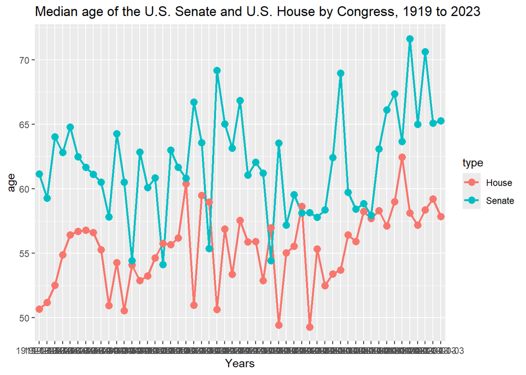

```r
library(ggplot2)
g<-ggplot(df_combined,aes(x=start_date, y=age, color=type, group=type))+
  geom_line(size=1)+
  geom_point(size=3)+
  labs(title="Median age of the U.S. Senate and U.S. House by Congress, 1919 to 2023", x="Years", Y="Age")
g
```

# **Conclusion:**